# Project 2: Biomedical & Clinical Informatics

## 4.3.2 Elastic Net Results

Table 7. Results of the Elastic Net Tuning & 10-fold Cross-Validation

| alpha | lambda | RMSE | Rsquared | MAE | RMSESD | RsquaredSD | MAESD |
| --- | --- | --- | --- | --- | --- | --- | --- |
| 0.00 | 1.07 | 0.67 | 0.62 | 0.53 | 0.04 | 0.03 | 0.03 |
| 0.00 | 1.43 | 0.71 | 0.57 | 0.56 | 0.04 | 0.04 | 0.03 |
| 0.00 | 1.79 | 0.73 | 0.53 | 0.57 | 0.05 | 0.04 | 0.03 |
| 0.00 | 2.14 | 0.75 | 0.51 | 0.59 | 0.05 | 0.04 | 0.03 |
| 0.00 | 2.50 | 0.76 | 0.49 | 0.60 | 0.05 | 0.04 | 0.03 |
| 0.00 | 2.86 | 0.78 | 0.47 | 0.61 | 0.05 | 0.04 | 0.03 |
| 0.00 | 3.21 | 0.79 | 0.46 | 0.61 | 0.05 | 0.04 | 0.03 |
| 0.00 | 3.57 | 0.79 | 0.45 | 0.62 | 0.05 | 0.04 | 0.03 |
| 0.00 | 3.93 | 0.80 | 0.44 | 0.63 | 0.05 | 0.04 | 0.03 |
| 0.00 | 4.29 | 0.81 | 0.43 | 0.63 | 0.05 | 0.04 | 0.03 |
| 0.00 | 4.64 | 0.81 | 0.43 | 0.64 | 0.05 | 0.04 | 0.03 |
| 0.00 | 5.00 | 0.82 | 0.42 | 0.64 | 0.05 | 0.04 | 0.03 |
| 0.11 | 4.64 | 0.96 | 0.57 | 0.75 | 0.05 | 0.04 | 0.03 |
| 0.11 | 5.00 | 0.97 | 0.57 | 0.75 | 0.05 | 0.04 | 0.03 |
| 0.22 | 2.50 | 0.95 | 0.57 | 0.74 | 0.05 | 0.04 | 0.03 |
| 0.22 | 2.86 | 0.97 | 0.57 | 0.75 | 0.05 | 0.04 | 0.03 |
| 0.22 | 3.21 | 0.99 | 0.57 | 0.77 | 0.05 | 0.04 | 0.03 |
| 0.22 | 3.57 | 1.00 | NaN | 0.77 | 0.05 | NA | 0.03 |
| 0.22 | 3.93 | 1.00 | NaN | 0.77 | 0.05 | NA | 0.03 |
| 0.22 | 4.29 | 1.00 | NaN | 0.77 | 0.05 | NA | 0.03 |
| 0.22 | 4.64 | 1.00 | NaN | 0.77 | 0.05 | NA | 0.03 |
| 0.22 | 5.00 | 1.00 | NaN | 0.77 | 0.05 | NA | 0.03 |
| 0.33 | 1.79 | 0.95 | 0.57 | 0.73 | 0.05 | 0.04 | 0.03 |
| 0.33 | 2.14 | 0.99 | 0.57 | 0.76 | 0.05 | 0.04 | 0.03 |
| 0.33 | 2.50 | 1.00 | NaN | 0.77 | 0.05 | NA | 0.03 |
| 0.33 | 2.86 | 1.00 | NaN | 0.77 | 0.05 | NA | 0.03 |
| 0.33 | 3.21 | 1.00 | NaN | 0.77 | 0.05 | NA | 0.03 |
| 0.33 | 3.57 | 1.00 | NaN | 0.77 | 0.05 | NA | 0.03 |
| 0.33 | 3.93 | 1.00 | NaN | 0.77 | 0.05 | NA | 0.03 |
| 0.33 | 4.29 | 1.00 | NaN | 0.77 | 0.05 | NA | 0.03 |

[output cut: 77 more lines]

#### What were the hyperparameters of our best tuned model?

$\alpha$:

```
## [1] 0.6666667
```

$\lambda$:

```
## [1] 0
```

##### **Question 28**: [1 point]

## Ryan C

Check the values of $\alpha$ and $\lambda$ here. What do they suggest about the optimal regularization that is being fit here? (Recall that when both $\alpha$ and $\lambda$ are zero, it’s an OLS regression!)

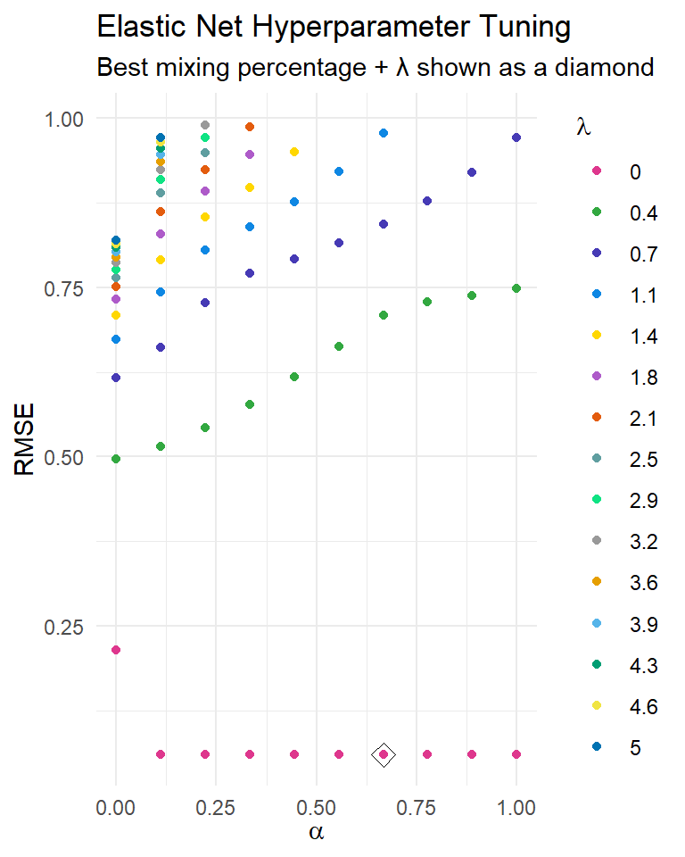

#### Important Features

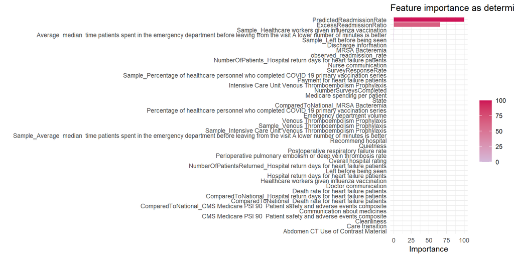

##### **Question 29**: [1 point]

## Ryan C

Which of the features were most important? How does this compare to the most important features out of regression? How about about of PCA?

```r
prOLS <- postResample(pred = predict(mod, newdata = HFregressionTest),
                      obs = HFregressionTest$bc_ExpectedReadmissionRate)

prElastic <- postResample(pred = predict(elasticMod, newdata = HFreadyTest),
                      obs = HFreadyTest$bc_ExpectedReadmissionRate)

## Display the output
rbind(prOLS, prElastic) %>%
  kable(digits = 2,
    format = "html",
    caption = "Table 8. Comparison of the OLS and Elastic Net Regressions") %>%
    kable_styling(bootstrap_options = c("hover", full_width = F)
)
```

Table 8. Comparison of the OLS and Elastic Net Regressions

|  | RMSE | Rsquared | MAE |
| --- | --- | --- | --- |
| prOLS | 0.08 | 1 | 0.06 |
| prElastic | 0.08 | 1 | 0.06 |

##### **Question 30**: [1 point]

## Ryan C

Using the same method, check for overfitting / underfitting. Make predictions using `readyTrain` rather than `readyTest`, and then check how the RMSE on the training data compares to the RMSE of the training data for the Elastic Net. How do they compare? (Recall what we discussed when we did the gene expression demo: the relationship of the test vs. training accuracy can be used to assess overfitting/underfitting. The same logic applies to RMSE too!) **How do both compare to what we got out of the OLS regression?** Which would you say is the better predictive model, the OLS regression or the Elastic Net? Why?

```r
prOLS_train <- postResample(pred = predict(mod, newdata = HFreadyTrain),
                            obs = HFreadyTrain$bc_ExpectedReadmissionRate)
prElastic_train <- postResample(pred = predict(elasticMod, newdata = HFreadyTrain),
                                obs = HFreadyTrain$bc_ExpectedReadmissionRate)

rbind(prOLS_train, prOLS, prElastic_train, prElastic) %>%
  kable(digits = 2,
        format = "html",
        caption = "Table 8. Comparison of the OLS and Elastic Net Regressions on Training Data") %>%
  kable_styling(bootstrap_options = c("hover", full_width = F))
```

Table 8. Comparison of the OLS and Elastic Net Regressions on Training Data

|  | RMSE | Rsquared | MAE |
| --- | --- | --- | --- |
| prOLS_train | 0.06 | 1 | 0.04 |
| prOLS | 0.08 | 1 | 0.06 |
| prElastic_train | 0.06 | 1 | 0.04 |
| prElastic | 0.08 | 1 | 0.06 |

A graphical comparison of the two models.

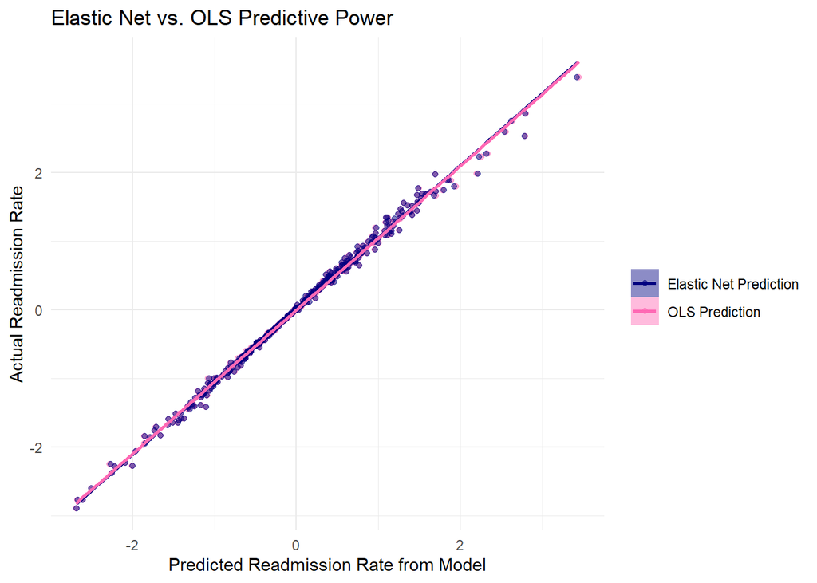

Unsurprisingly from the RMSE, these models are performing VERY similarly.

##### **Question 31**: [4 points]

## Ryan C

What conclusions do you make at this point about whether to make predictions with an OLS regression, Elastic Net, or neither? What recommendations would you make to our client at this point? What other analyses might your suggest, or other data we might want to include? Please try to flesh out 2-3 recommendations in at least a paragraph.

At this point, the decision to use predictions from an OLS regression depends on the specific objectives and constraints of the project. Here are some conclusions and recommendations based on the analysis:

> To the clients, I would recommend another regularization technique like Lasso to try to fix the overfitting problem. By fixing this, this would also improve the performance of the model. We could also explore other optons like trying different ensemble methods like boosting and bagging. The aim of using these methods are to improve prediction accuracy by combining multiple models, reducing overfitting, and offer an easy way to get insights into data by looking at eac individual model contributions. Another recommendation I would give is to look at how the data was collected so we can improve the model by giving it different or better data. We can update the datasets to add any new or relevant data. We can look at domain-specific variables to see if demographics, medical history, and treatment protocols could provide valuable insights into readmission rates.

> Finally we can check back in with the paitents at a later time to see if any new patterns emerge that were not there intially. Even though the OLS regression model still has some limitations, it still provideding valuable predictions and insights. If we employ the recommendations above I am confident that the models prediction accuracy will further improve and do a better job at meeting our objectives.

#### Adventure 1. [Choosing to analyze HF.]

- Make sure that you use the code I provided, updating it for your new condition
- Make sure to answer all of the interpretative questions again for your new dataset.
- I will specifically be looking for a comparison of which condition, pneumonia or the one you chose, seems to be a better choice for a predictive model for our client. Or is it neither?
- Make sure to include some next steps or recommendations based on your new analysis!

## 5.2 Deliverables

Unlike what you may have seen on Canvas, I am going to make things much lighter on you this time so we can all catch a breath. I am looking for 1-2 markdown documents with their knitted HTML. For example, if you’re choosing Adventures 1 or 2, you may want to work through this document once, make a copy, and then do it again for the new condition(s) you choose to work through. If you’re choosing Adventure 3, maybe you just choose to add on to the bottom of this document, replacing the ‘Next Steps’ section you see here.

Just make sure to answer the questions well, and make sure to justify the decisions you make. Tell me WHY you’re choosing the condition(s) you are in Adventures 1 or 2. Tell me WHY you’re doing the analyses you are in Adventure 3. Other than that, make this your own exploratory learning adventure!